# Stock & Movie Analysis Regression Modeling

Author

Amina, Lizzie, Rachna, Sophia

1. Further Cleaning and Filtering of Stocks & Movies: The datasets from this process will only contain stocks and movies between the years of 1999 - 2019.

```python
import pandas as pd
import polars as pl
import numpy as np
import matplotlib.pyplot as plt
```

```python
#Selecting the timeframe 1999 - 2019

merged_df = pd.read_csv('merged_data/merged.csv')


#merged_df['Date'] = pd.to_datetime(merged_df['Year'], errors='coerce')

merged_df['Date'] = pd.to_datetime(merged_df['Year'], format='%Y', errors='coerce')

merged_filtered = merged_df[(merged_df['Date'].dt.year >= 1999) & (merged_df['Date'].dt.year <= 2019)]

merged_filtered.head()
merged_filtered.tail()
```

|  | Unnamed: 0 | Open | High | Low | Close | Adj Close | Volume | Year | Genre | Runtime | ... | TECH | UBER | VIAC | VOYA | WIX | XOM | YETI | ZION | SPX | Date |
| --- | --- | --- | --- | --- | --- | --- | --- | --- | --- | --- | --- | --- | --- | --- | --- | --- | --- | --- | --- | --- | --- |
| 43763 | 43763 | 532.86 | 539.23 | 530.89 | 532.68 | 529.28 | 1.163000e+05 | 2019 | 7 | 141.0 | ... | 0 | 0 | 0 | 0 | 0 | 0 | 0 | 0 | 0 | 2019-01-01 |
| 43764 | 43764 | 1363.35 | 1363.64 | 1349.00 | 1349.59 | 1349.59 | 3.315000e+06 | 2019 | 99 | 109.0 | ... | 0 | 0 | 0 | 0 | 0 | 0 | 0 | 0 | 0 | 2019-01-01 |
| 43765 | 43765 | 1363.35 | 1363.64 | 1349.00 | 1349.59 | 1349.59 | 3.315000e+06 | 2019 | 7 | 141.0 | ... | 0 | 0 | 0 | 0 | 0 | 0 | 0 | 0 | 0 | 2019-01-01 |
| 43766 | 43766 | 3223.33 | 3225.65 | 3216.03 | 3221.22 | 3221.22 | 6.454270e+09 | 2019 | 99 | 109.0 | ... | 0 | 0 | 0 | 0 | 0 | 0 | 0 | 0 | 1 | 2019-01-01 |
| 43767 | 43767 | 3223.33 | 3225.65 | 3216.03 | 3221.22 | 3221.22 | 6.454270e+09 | 2019 | 7 | 141.0 | ... | 0 | 0 | 0 | 0 | 0 | 0 | 0 | 0 | 1 | 2019-01-01 |

5 rows × 50 columns

```python
merged_filtered.shape
merged_filtered.isnull().any(axis=1).sum()

#Checking na per year for box office

merged_filtered['Year'] = merged_filtered['Date'].dt.year

missing_box_office_per_year = merged_filtered[merged_filtered['Box Office'].isnull()].groupby('Year').size()

# Display result
print(missing_box_office_per_year)

#Dropping drops atleast half the dataset so instead  moving forward with this but we could just duplicate the movies box office $ in that year to a movie.

# Treating them as seperate dfs removing the movies from the merged df


merged_filtered.columns
merged_stock = merged_filtered.iloc[:, 1:-17]

merged_stock.tail()
```

```
Series([], dtype: int64)
```

|  | Open | High | Low | Close | Adj Close | Volume | Year | Genre | Runtime | Rated | ... | DISCA | ENPH | FCNCA | GOOG | HUBB | JBL | KEYS | LDOS | MASI | NATI |
| --- | --- | --- | --- | --- | --- | --- | --- | --- | --- | --- | --- | --- | --- | --- | --- | --- | --- | --- | --- | --- | --- |
| 43763 | 532.86 | 539.23 | 530.89 | 532.68 | 529.28 | 1.163000e+05 | 2019 | 7 | 141.0 | 4 | ... | 0 | 0 | 1 | 0 | 0 | 0 | 0 | 0 | 0 | 0 |
| 43764 | 1363.35 | 1363.64 | 1349.00 | 1349.59 | 1349.59 | 3.315000e+06 | 2019 | 99 | 109.0 | 5 | ... | 0 | 0 | 0 | 1 | 0 | 0 | 0 | 0 | 0 | 0 |
| 43765 | 1363.35 | 1363.64 | 1349.00 | 1349.59 | 1349.59 | 3.315000e+06 | 2019 | 7 | 141.0 | 4 | ... | 0 | 0 | 0 | 1 | 0 | 0 | 0 | 0 | 0 | 0 |
| 43766 | 3223.33 | 3225.65 | 3216.03 | 3221.22 | 3221.22 | 6.454270e+09 | 2019 | 99 | 109.0 | 5 | ... | 0 | 0 | 0 | 0 | 0 | 0 | 0 | 0 | 0 | 0 |
| 43767 | 3223.33 | 3225.65 | 3216.03 | 3221.22 | 3221.22 | 6.454270e+09 | 2019 | 7 | 141.0 | 4 | ... | 0 | 0 | 0 | 0 | 0 | 0 | 0 | 0 | 0 | 0 |

5 rows × 32 columns

```python
merged_stock.head()
merged_stock.isnull().any(axis=1).sum()
#merged_stock['Year'] = merged_stock['Date'].dt.year

missing_stock = merged_stock[merged_stock['Adj Close'].isnull()].groupby('Year').size()

print(missing_stock)

#Dropping where adj close is empty & saving it

#Dropping the year col that was added.
merged_stock = merged_stock.dropna(subset=['Adj Close'])

merged_stock.to_csv('merged_data/merged_stock_99_2019.csv', index=False)
```

```
Series([], dtype: int64)
```

```python
#Cleaning the movie dataset for 1999 -2019 alone.

movie_df = pd.read_csv('movie_data/movies_with_details.csv')

movie_df.head()


movie_df['Year'] = pd.to_numeric(movie_df['Year'], errors='coerce')
movie_df = movie_df[(movie_df['Year'] >= 1999) & (movie_df['Year'] <= 2019)]

movie_df = movie_df.sort_values(by='Year')
movie_df.head()
movie_df.tail()
```

|  | Title | Year | Released | Genre | Runtime | Director | Writer | Actors | Rated | IMDB Rating | Metascore | IMDB Votes | Awards | Box Office | Country | Language | Description | Poster URL |
| --- | --- | --- | --- | --- | --- | --- | --- | --- | --- | --- | --- | --- | --- | --- | --- | --- | --- | --- |
| 1369 | Shazam! | 2019.0 | 05 Apr 2019 | Action, Adventure, Comedy | 132 min | David F. Sandberg | Henry Gayden, Darren Lemke, Bill Parker | Zachary Levi, Mark Strong, Asher Angel | PG-13 | 7.0 | 71.0 | 394,681 | 27 nominations total | $140,480,049 | United States, Canada | English, Spanish | In Philadelphia, Billy Batson is an abandoned ... | https://m.media-amazon.com/images/M/MV5BZWM1Yj... |
| 1341 | Bombshell | 2019.0 | 20 Dec 2019 | Biography, Drama | 109 min | Jay Roach | Charles Randolph | Charlize Theron, Nicole Kidman, Margot Robbie | R | 6.8 | 64.0 | 130,592 | Won 1 Oscar. 26 wins & 63 nominations total | $31,762,808 | Canada, United States | English | When Gretchen Carlson slaps Fox News founder R... | https://m.media-amazon.com/images/M/MV5BODY3OD... |
| 1326 | Polar | 2019.0 | 25 Jan 2019 | Action, Crime, Thriller | 118 min | Jonas Åkerlund | Jayson Rothwell, Víctor Santos | Mads Mikkelsen, Vanessa Hudgens, Katheryn Winnick | TV-MA | 6.3 | 19.0 | 101,736 | 1 nomination total | NaN | United States, Germany | English, Russian | A retiring assassin suddenly finds himself on ... | https://m.media-amazon.com/images/M/MV5BZmEzNz... |
| 1786 | Just Mercy | 2019.0 | 10 Jan 2020 | Biography, Crime, Drama | 137 min | Destin Daniel Cretton | Destin Daniel Cretton, Andrew Lanham, Bryan St... | Michael B. Jordan, Jamie Foxx, Brie Larson | PG-13 | 7.6 | 68.0 | 78,727 | 9 wins & 19 nominations total | $36,001,502 | United States | English | A powerful and thought-provoking true-story, "... | https://m.media-amazon.com/images/M/MV5BNmJmYm... |
| 1964 | A Rainy Day in New York | 2019.0 | 10 Nov 2020 | Comedy, Romance | 92 min | Woody Allen | Woody Allen | Timothée Chalamet, Elle Fanning, Liev Schreiber | PG-13 | 6.4 | 38.0 | 54,006 | 3 wins | NaN | United States | English | In the Yardley College, Gatsby Welles learns t... | https://m.media-amazon.com/images/M/MV5BMTBmOD... |

```python
#Dropping Nas in boc office and then saving it

missing_movies= movie_df[movie_df['Box Office'].isnull()].groupby('Year').size()

movie_df.isnull().any(axis=1).sum()

print(missing_movies)

movie_df = movie_df.dropna(subset=['Box Office'])


movie_df.to_csv('merged_data/movies_99_2019.csv', index=False)
```

```
Year
1999.0     1
2000.0     2
2001.0     3
2002.0     6
2003.0     2
2004.0     3
2005.0     4
2006.0     5
2007.0     9
2008.0     3
2009.0     5
2010.0     5
2011.0    10
2012.0     9
2013.0    13
2014.0     9
2015.0    10
2016.0    11
2017.0    27
2018.0    39
2019.0    37
dtype: int64
```

2. Exploring the Correlation Between Stocks and Movie’s Box Office: We will be exploring the stock markets affect to the box office.

```python
stock_df = pd.read_csv('merged_data/merged_stock_99_2019.csv')

movies_df = pd.read_csv('merged_data/movies_99_2019.csv')

#Aggregating by year. (Taking the avg of all stocks every year)

stock_yearly = stock_df.groupby("Year")["Adj Close"].mean().reset_index()
movies_df["Box Office"] = movies_df["Box Office"].replace('[\$,]', '', regex=True).astype(float)
movies_yearly = movies_df.groupby("Year")["Box Office"].sum().reset_index()

#Raw Trend Comparison of Avg Stock & Avg Box Office
#Converting so there no floats in yrs
stock_yearly["Year"] = stock_yearly["Year"].astype(int)
movies_yearly["Year"] = movies_yearly["Year"].astype(int)

# Making sure the years are the same
years = sorted(set(stock_yearly["Year"]).intersection(movies_yearly["Year"]))

stock_yearly = stock_yearly[stock_yearly["Year"].isin(years)]
movies_yearly = movies_yearly[movies_yearly["Year"].isin(years)]
```

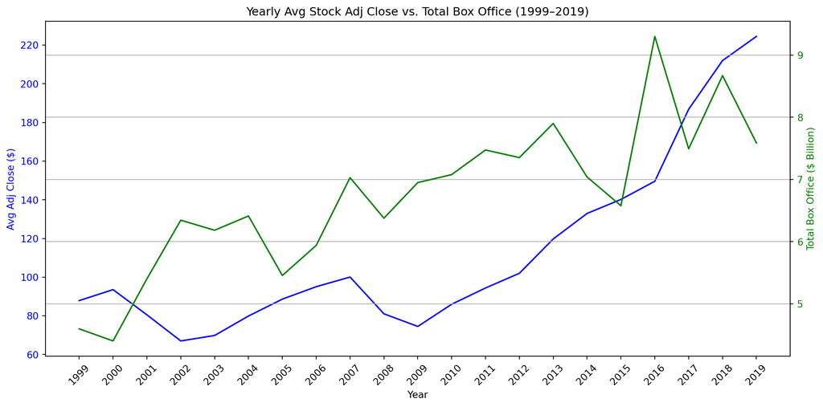

```python
#Making the movies in billions
movies_yearly["Box Office (Billion $)"] = movies_yearly["Box Office"] / 1e9

fig, ax1 = plt.subplots(figsize=(12, 6))

#Plotting the stock data and movie

#stock
ax1.plot(stock_yearly["Year"], stock_yearly["Adj Close"], color="blue", label="Avg Stock Adj Close")
ax1.set_ylabel("Avg Adj Close ($)", color="blue")
ax1.tick_params(axis="y", labelcolor="blue")

#movie
ax2 = ax1.twinx()
ax2.plot(movies_yearly["Year"], movies_yearly["Box Office (Billion $)"], color="green", label="Total Box Office")
ax2.set_ylabel("Total Box Office ($ Billion)", color="green")
ax2.tick_params(axis="y", labelcolor="green")

# Setting interger and titles.
ax1.set_xticks(years)
ax1.set_xticklabels([str(year) for year in years], rotation=45)

plt.title("Yearly Avg Stock Adj Close vs. Total Box Office (1999–2019)")
ax1.set_xlabel("Year")
plt.grid(True)
plt.tight_layout()

#Saving the Yearly Avg Stock Vs Total Box office

plt.savefig("figures/yearly_avg_stock.png", transparent=True, dpi=300, bbox_inches='tight')

plt.show()
```

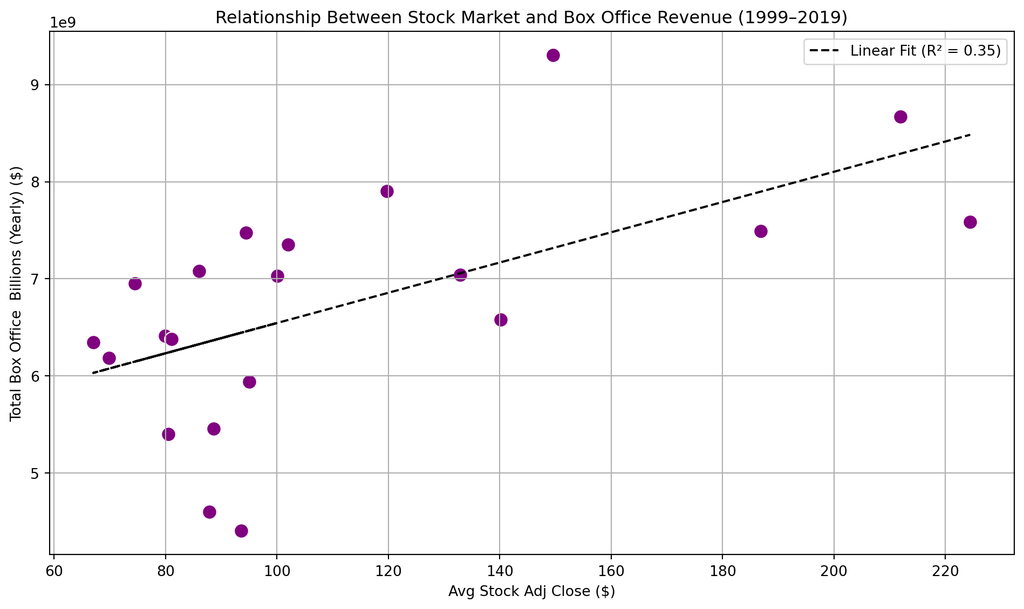

```python
#Exploring linear correlation among stock and movies with avgs and linear regression

import seaborn as sns
from sklearn.linear_model import LinearRegression
from sklearn.metrics import r2_score
import random

random.seed(5300)
# Preparing X & y to fit the linear regression
X = stock_yearly["Adj Close"].values.reshape(-1, 1)
y = movies_yearly["Box Office"].values

#Fitting the linear regression
model = LinearRegression()
model.fit(X, y)
y_pred = model.predict(X)

# Calculating r2 to see if there is a linear correlation
r2 = r2_score(y, y_pred)

#Plotting them both with linear fit
plt.figure(figsize=(10, 6))
sns.scatterplot(x=stock_yearly["Adj Close"], y=movies_yearly["Box Office"], color="purple", s=100)
plt.plot(stock_yearly["Adj Close"], y_pred, color="black", linestyle="--", label=f"Linear Fit (R² = {r2:.2f})")

plt.xlabel("Avg Stock Adj Close ($)")
plt.ylabel("Total Box Office  Billions (Yearly) ($)")
plt.title("Relationship Between Stock Market and Box Office Revenue (1999–2019)")
plt.legend()
plt.grid(True)
plt.tight_layout()

#Saving
plt.savefig("figures/yearly_avg_stock_linear_rel.png", transparent=True, dpi=300, bbox_inches='tight')

plt.show()
```

Even though there is a low clear linear relationship between the stock market and box office revenue, we will explore whether box office earnings can be predicted using stock market data through polynomial regression of different degrees

3. Fitting mutiple degree polynomials to predict movies box office revenue.

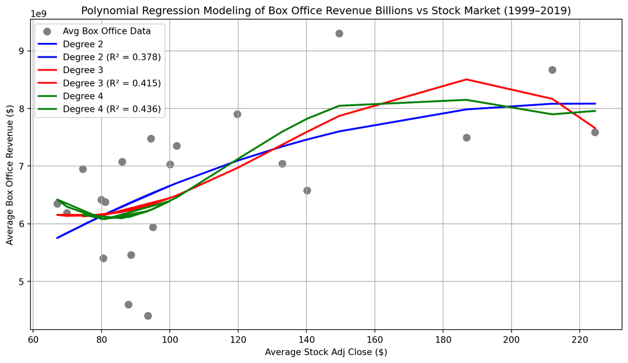

```python
# Exploratory analysis to first see if it performs well before predicting on unseen data.

from sklearn.preprocessing import PolynomialFeatures
from sklearn.model_selection import train_test_split

#Fitting them on yearly avg box office plotted against yearly adj stock close
X = stock_yearly["Adj Close"].values.reshape(-1, 1) #Reshaping bc of
y = movies_yearly["Box Office"].values

#Plotting polynomial fits for different degrees
degrees = [2, 3, 4]
colors = ['blue', 'red', 'green']

plt.figure(figsize=(10, 6))
plt.scatter(X, y, color="gray", label="Avg Box Office Data", s=60)

#This was for the exploratory analysis later the data will be split and that is the model we will actually use.
for deg, color in zip(degrees, colors):
    poly = PolynomialFeatures(degree=deg) #Feat Transformation
    X_poly = poly.fit_transform(X) #Transforming X feats as well.
    model = LinearRegression().fit(X_poly, y)
    y_pred = model.predict(X_poly)
    plt.plot(X.flatten(), y_pred, color=color, linewidth=2, label=f"Degree {deg}")

# Models' performance

    r2 = r2_score(y, y_pred)

    # Plotting R
    plt.plot(X.flatten(), y_pred, color=color, linewidth=2,
             label=f"Degree {deg} (R² = {r2:.3f})")

#Including titles and labes and also monetray vals

plt.xlabel("Average Stock Adj Close ($)")
plt.ylabel("Average Box Office Revenue ($)")
plt.title("Polynomial Regression Modeling of Box Office Revenue Billions vs Stock Market (1999–2019)")
plt.legend()
plt.grid(True)
plt.tight_layout()


plt.show()
```

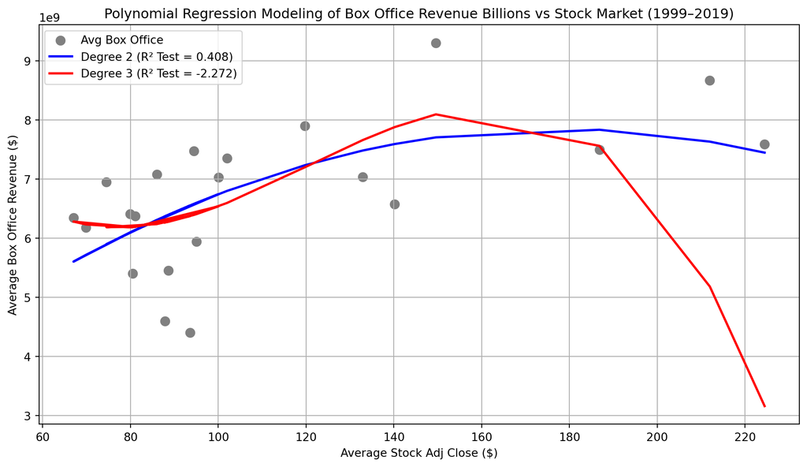

```python
# Re-fitting the model by actually splitting the data first and then observing how it performs on unseen data
#Fitting them on yearly avg box office plotted against yearly adj stock close

#Splittng the data 70 / 30
x_train, x_test, y_train, y_test = train_test_split(X, y, test_size=0.3, random_state=5300)

#Plotting polynomial fits for different degrees
degrees = [2, 3] #Removing 4 it performed horribly
colors = ['blue', 'red']

plt.figure(figsize=(10, 6))
plt.scatter(X, y, color="gray", label="Avg Box Office", s=60)


for deg, color in zip(degrees, colors):
    # feat transformation & training the model
    poly = PolynomialFeatures(degree=deg)
    x_train_poly = poly.fit_transform(x_train)
    model = LinearRegression().fit(x_train_poly, y_train)
    #Predicting on the actual vals
    x_test_poly = poly.transform(x_test)
    y_pred = model.predict(x_test_poly)

    #Model's performance

    r2 = r2_score(y_test, y_pred)

    # Predicting on the full dataset
    x_full_poly = poly.transform(X)
    y_full_pred = model.predict(x_full_poly)

#plotting the predicted vals
    plt.plot(X.flatten(), y_full_pred, color=color, linewidth=2,
             label=f"Degree {deg} (R² Test = {r2:.3f})")

#Including titles and labels and also monetray vals

plt.xlabel("Average Stock Adj Close ($)")
plt.ylabel("Average Box Office Revenue ($)")
plt.title("Polynomial Regression Modeling of Box Office Revenue Billions vs Stock Market (1999–2019)")
plt.legend()
plt.grid(True)
plt.tight_layout()

plt.savefig("figures/basline_polynom.png", transparent=True, dpi=300, bbox_inches='tight')

plt.show()
```

From the polynomial fits, we can see that they don’t perform perfectly overall, but the 2 degree polynomial gave the best result. This shows that lower-degree models can capture more of the patterns in the data. Still, it’s clear that the stock market alone isn’t enough to predict box office performance. Other factors like the movie’s genre, time of year it was released, and the actors involved likely play a big role. –> It might be worth exploring these??

4. Re-Fitting the Model with select stocks from feature selection stock analysis. Stocks: SPX, XOM, T, GOOG, LDOS.

```python
#Select stock from best features.
df = pd.read_csv('merged_data/merged.csv')

Cols = ['Year', 'Box Office','SPX', 'XOM', 'T', 'GOOG', 'LDOS']

selected_stock = df[Cols].copy()

# Dropping NAs  rows with any missing values
selected_stock = selected_stock.dropna()
selected_stock.head()

# Making sure its 99 - 2019
selected_stock = selected_stock[(selected_stock["Year"] >= 1999) & (selected_stock["Year"] <= 2019)]

# Aggregating to use the avg of 5 stocks to get the avg box office
agg_df = selected_stock.groupby("Year").agg({
    "Box Office": "mean",
    "SPX": "mean",
    "XOM": "mean",
    "T": "mean",
    "GOOG": "mean",
    "LDOS": "mean"
}).reset_index()

#agg_df.head()
```

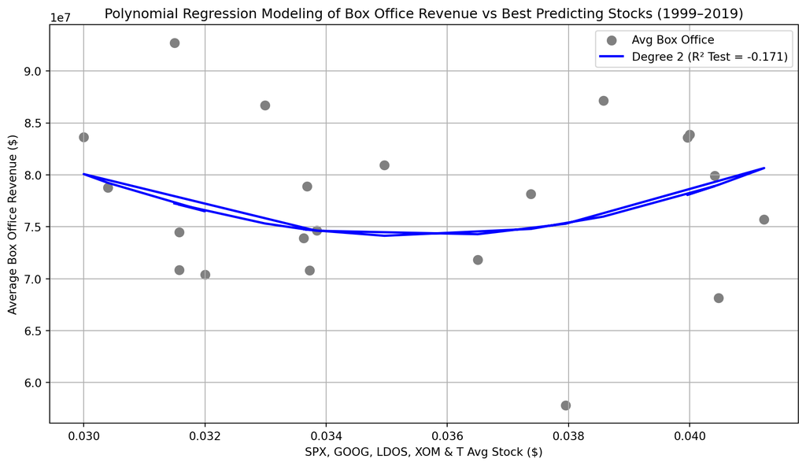

```python
#Re-setting the polynom model

#Defining the preds
#X = agg_df[["SPX", "XOM", "T", "GOOG", "LDOS"]].values

X = agg_df[["SPX", "XOM", "T", "GOOG", "LDOS"]].mean(axis=1).values.reshape(-1, 1)
y = agg_df["Box Office"].values

#Splitting the df again
x_train, x_test, y_train, y_test = train_test_split(X, y, test_size=0.3, random_state=5300)

#Plotting polynomial fits for different degrees
degrees = [2]
colors = ['blue']

plt.figure(figsize=(10, 6))
plt.scatter(X, y, color="gray", label="Avg Box Office", s=60)


for deg, color in zip(degrees, colors):
    # feat transformation & training the model
    poly = PolynomialFeatures(degree=deg)
    x_train_poly = poly.fit_transform(x_train)
    model = LinearRegression().fit(x_train_poly, y_train)
    #Predicting on the actual vals
    x_test_poly = poly.transform(x_test)
    y_pred = model.predict(x_test_poly)

    #Model's performance

    r2 = r2_score(y_test, y_pred)

    # Predicting on the full dataset
    x_full_poly = poly.transform(X)
    y_full_pred = model.predict(x_full_poly)

#plotting the predicted vals
    plt.plot(X, y_full_pred, color=color, linewidth=2,
         label=f"Degree {deg} (R² Test = {r2:.3f})")


#Including titles and labels and also monetray vals

plt.xlabel("SPX, GOOG, LDOS, XOM & T Avg Stock ($)")
plt.ylabel("Average Box Office Revenue ($)")
plt.title("Polynomial Regression Modeling of Box Office Revenue vs Best Predicting Stocks (1999–2019)")
plt.legend()
plt.grid(True)
plt.tight_layout()

plt.savefig("figures/final_polynom.png", transparent=True, dpi=300, bbox_inches='tight')

plt.show()
```